# Aplicación del filtro Hodrick-Prescott

Se aplicó el filtro Hodrick-Prescott sobre la serie del IMAE para obtener la brecha del producto (el componente cíclico). Para ello debemos recordar que dada la construcción del filtro es necesario que la serie esté desestacionalizada, por lo que se utilizará el método x11-ARIMA sobre la serie original[^1].

# Visualización de la serie del IMAE

Cómo puede observarse la serie presenta un componente estacional que debe ser eliminado para poder aplicar el filtro Hodrick-Prescott y estimar la brecha del producto.

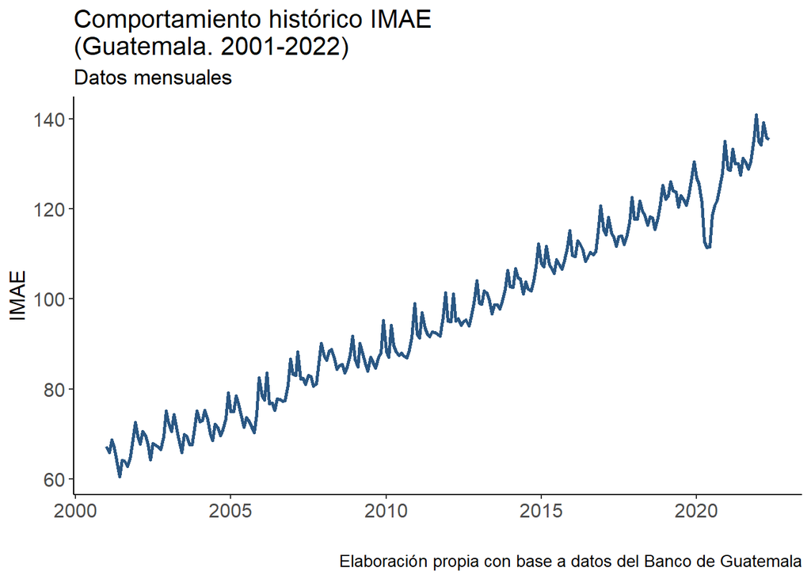

# Método x11-ARIMA para desestacionalizar la serie

Mediante la función “seas” del paquete “seasonal” se aplicó el método x11-ARIMA para la descomposición de la serie de tiempo y aplicarleel ajuste estacional. El ajuste estacional se encuentra dentro del objeto creado que en nuestro caso es “IMAE.ajuste”.

## Serie con ajuste estacional

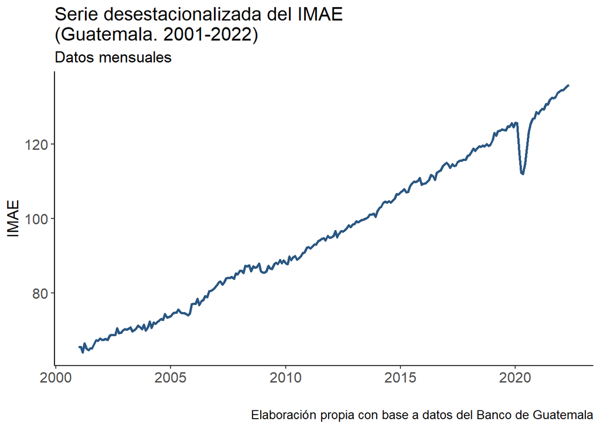

# Obtención del ciclo

Se aplica el filtro Hodrick-Prescott a la serie desestacionalizada del IMAE.

```r
IMAE_fHP <- hpfilter(IMAE_TC$ajuste_estacional, type = "lambda", freq = 14400)

# Variación relativa de la brecha

var_brecha <- IMAE_fHP$cycle/IMAE_fHP$trend

IMAE_TC <- cbind.data.frame(IMAE_TC, tendencia = IMAE_fHP$trend,
                            ciclo = IMAE_fHP$cycle, var_brecha = var_brecha)
```

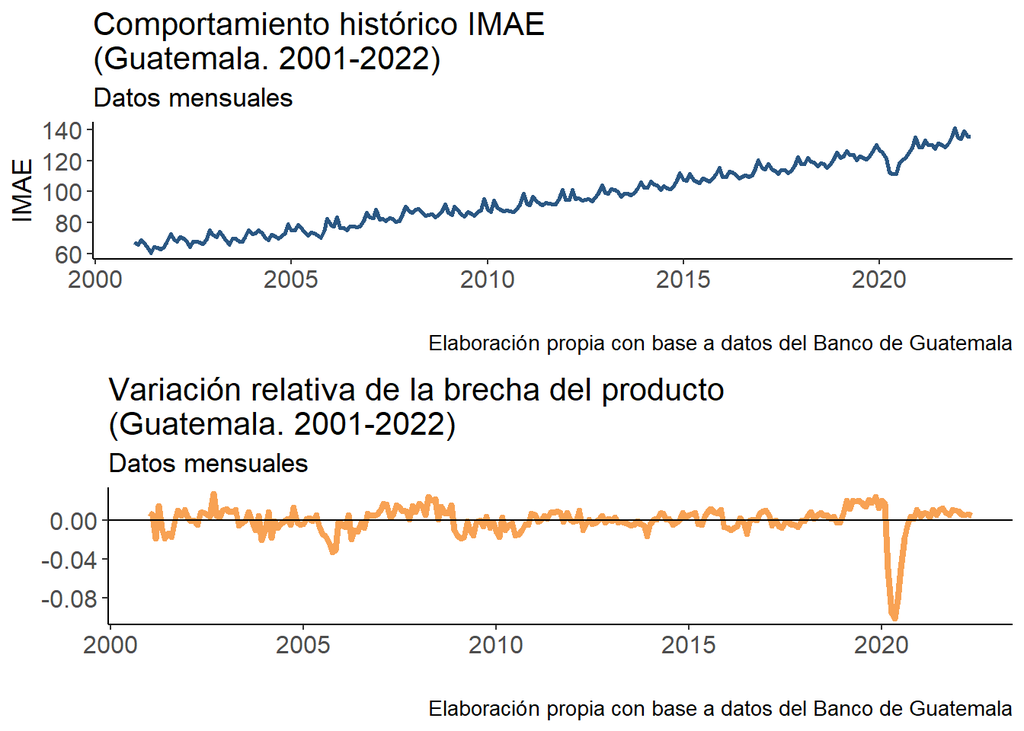

```r
grid.arrange(IMAE.plot, brecha.plot, nrow = 2)
```

# brecha del producto suavizada

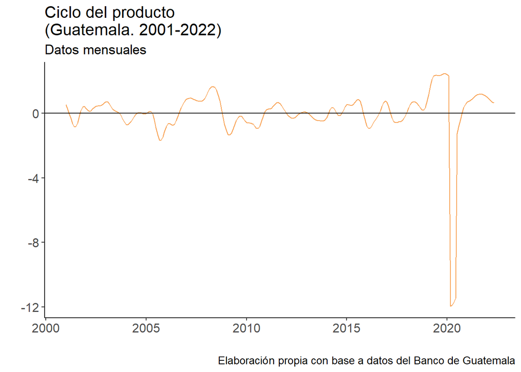

[^1]: La serie utilizada es el empalme entre los índices base 2001 y 2013 obtenida del [Banco de Guatemala](https://www.banguat.gob.gt/es/page/indice-mensual-de-la-actividad-economica-imae-ano-de-referencia-2013). Se utiliza la srie original por que la serie de tendencia-ciclo ya fue tratada de tal forma que fue eliminado de el componente irregular.